# Pre-processing de données H-NMR par PEPS-NMR - données carre-latin

Patrick Guerin

avril 13, 2018,19:27

# 1 Paramétrage du prétraitement et de l’affichage des étapes de prétraitements

# 2 Lecture des FID

Ci-dessous, vous retrouvez la représentation des données brutes dans le temps. Quand nous aggrandissons l’image (second graphique), nous remarquons que les vibrations ne commencent pas tout de suite, il existe un certain retard qui sera supprimé à la première étape du prétraitement.

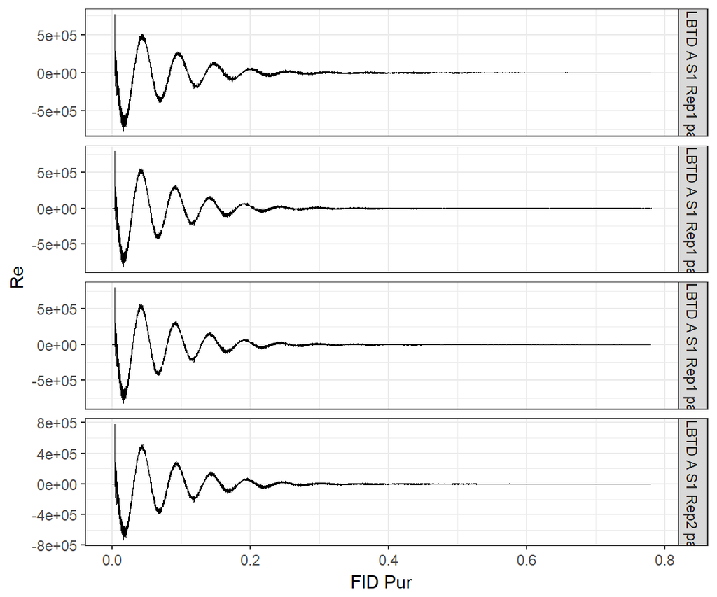

```r
# Lecture des Fid
fidList <- ReadFids(path = data.path, subdirs = subdirs)
Fid_data <- fidList[["Fid_data"]]
Fid_info <- fidList[["Fid_info"]]
# ReprÃ©sentation graphique des FID
if(DrawFid==T) Draw(Re(Fid_data[WhichSpectra,Fid_window]), type.draw = "signal", subtype = "stacked", num.stacked=NumStack,xlab="FID Pur")
```

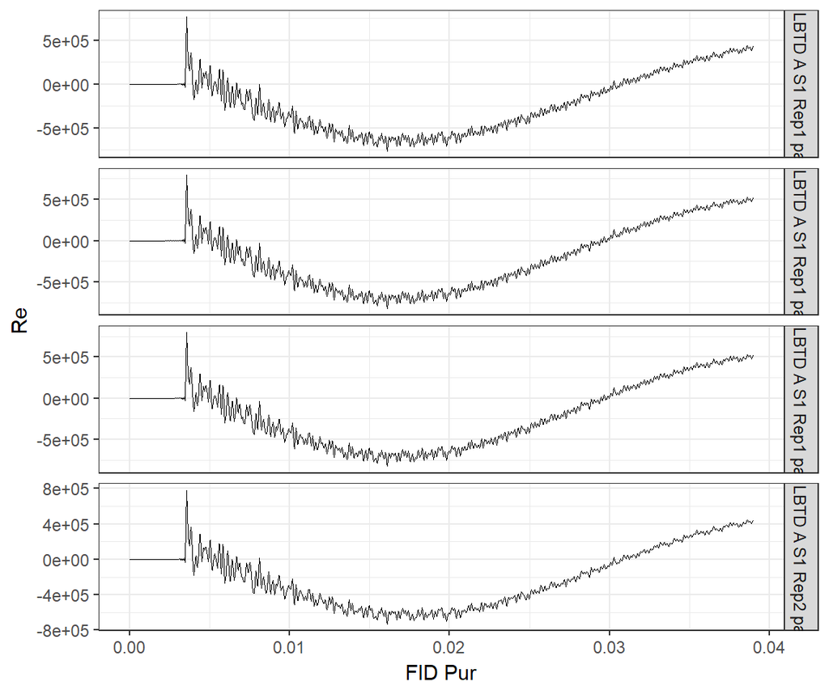

```r
# Reprèsentation graphique des FID agrandis
if(DrawFid==T) Draw(Re(Fid_data[WhichSpectra,round(Fid_window/20)]), type.draw = "signal", subtype = "stacked", num.stacked=NumStack,xlab="FID Pur")
```

# 3 Prétraitements du FID

## 3.1 Correction du Group Delay

Comme expliqué ci-dessus, la première étape consiste à supprimer le retard de vibration.

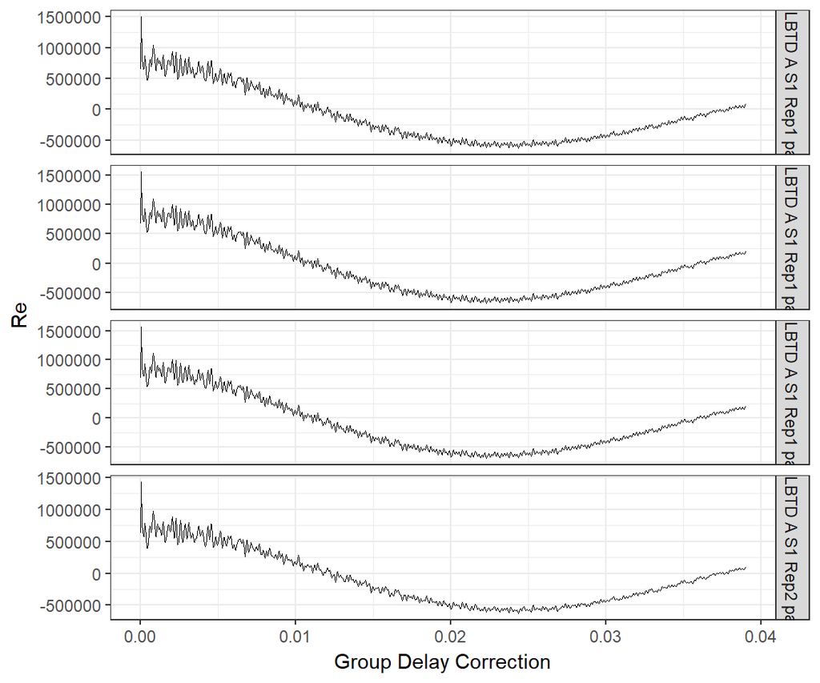

```r
# FirstOrderPhaseCorrection
Fid_data <- GroupDelayCorrection(Fid_data, Fid_info)
# ReprÃ©sentation graphique des FID
if(DrawFid==T) Draw(Re(Fid_data[WhichSpectra,Fid_window/20]), type.draw = "signal", subtype = "stacked", num.stacked=NumStack,xlab="Group Delay Correction")
```

Après agrandissement, nous pouvons constater que le retard a bien été supprimé.

## 3.2 Solvent Suppression

La plupart des échantillons analysés contiennent un solvant qui est généralement de l’eau. Ceci peut être visualisé sur le graphique par une vague qui oscille lentement dans le temps. La seconde étape du prétraitement consistera donc à supprimer cet effet dû au solvant par un lissage des données.

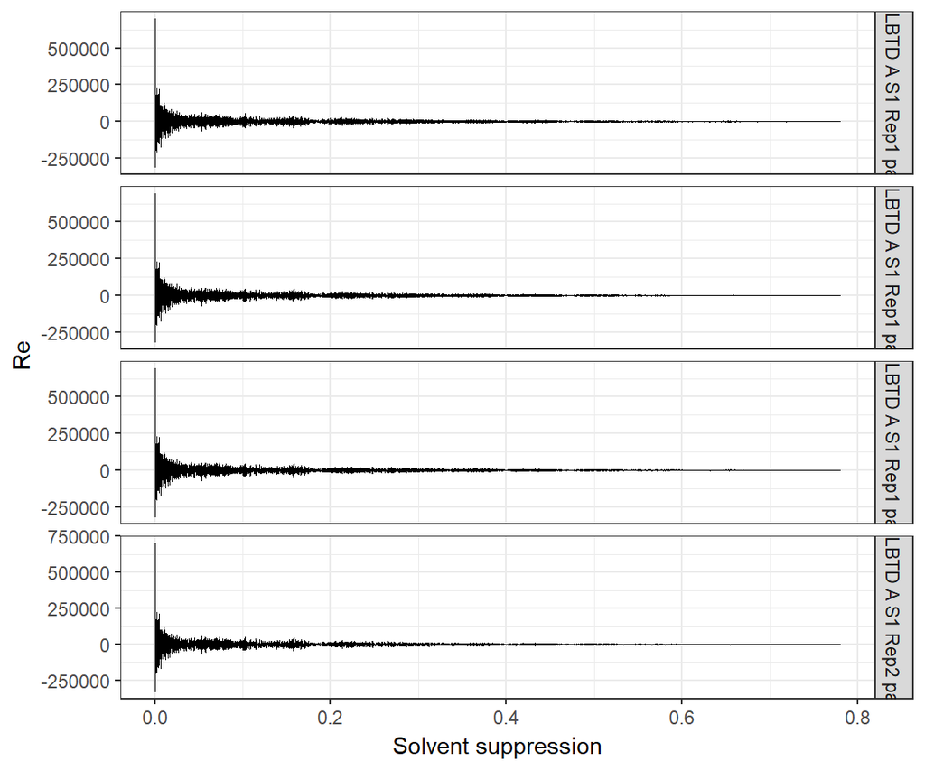

```r
# FirstOrderPhaseCorrection
Fid_data <- SolventSuppression(Fid_data)
# ReprÃ©sentation graphique des FID
if(DrawFid==T) Draw(Re(Fid_data[WhichSpectra,Fid_window]), type.draw = "signal", subtype = "stacked", num.stacked=NumStack,xlab="Solvent suppression")
```

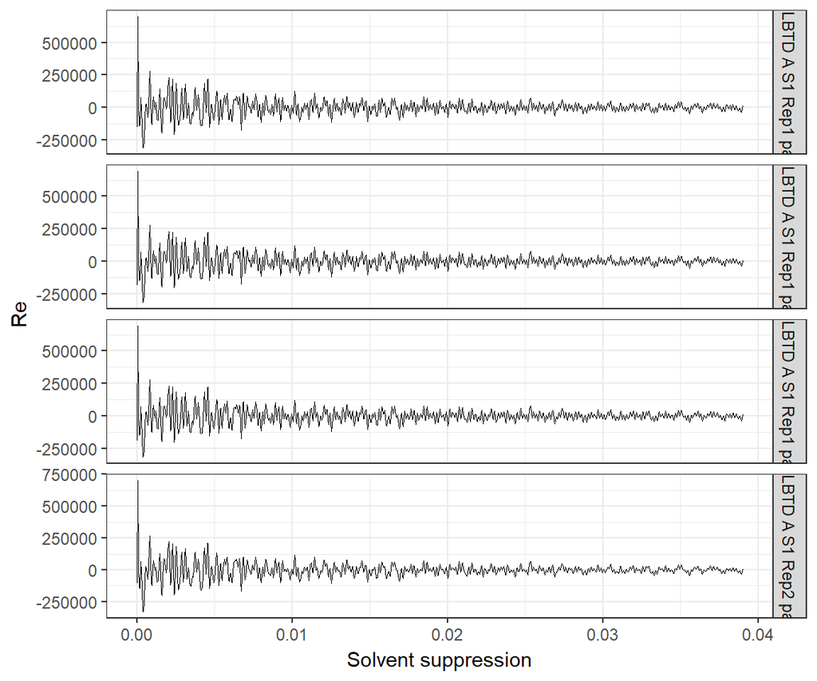

```r
if(DrawFid==T) Draw(Re(Fid_data[WhichSpectra,Fid_window/20]), type.draw = "signal", subtype = "stacked", num.stacked=NumStack,xlab="Solvent suppression")
```

Nous pouvons remarquer,par rapport aux graphiques du point précédent, que l’oscillation générée par le solvant a bien été supprimé.

## 3.3 Apodization

Les données contiennent un bruit analytique. En effet, les vibrations doivent décroître dans le temps. Cependant nous pouvons remarquer que dans la queue des graphiques précédents (sans agrandissement), il existe encore une oscillation qui semble constante. Cette dernière est un bruit généré par l’analyse que nous allons supprimer dans l’étape de prétraitement qui est l’apodisation.

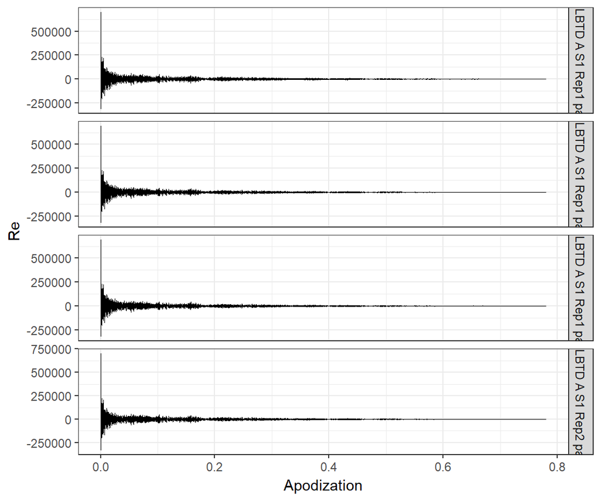

```r
# FirstOrderPhaseCorrection
Fid_data <- Apodization(Fid_data,Fid_info)
# ReprÃ©sentation graphique des FID
if(DrawFid==T) Draw(Re(Fid_data[WhichSpectra,Fid_window]), type.draw = "signal", subtype = "stacked", num.stacked=NumStack,xlab="Apodization")
```

Le bruit généré par l’analyse a bien été supprimé. En effet, nous remarquons que la queue des graphiques (endroit où le bruit est le plus visible) ressemble dorénavant plus un trait continue et non plus à une oscillation constante.

## 3.4 Transformée de Fourier

Pour l’instant, nous avons travaillé dans le domaine temporel. Dans cette nouvelle étape du prétraitement, nous allons réalisé une transformée de fourier afin d’exprimer les signaux dans le domaine des fréquences.

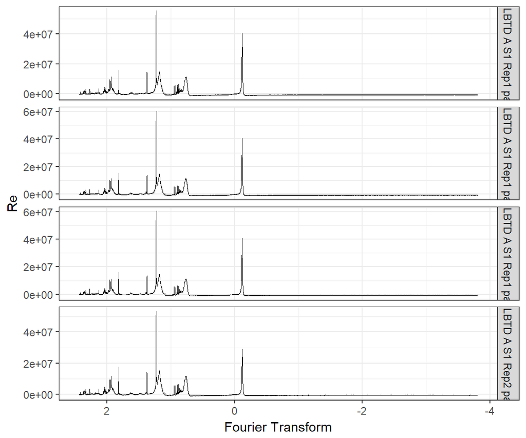

```r
# FourierTransform
Spectrum_data <- FourierTransform(Fid_data, Fid_info)
# ReprÃ©sentation graphique des FID
Raw_Spec_window=20000:30000
if(DrawSpectra==T) Draw(Re(Spectrum_data[WhichSpectra,Raw_Spec_window]), type.draw = "signal", subtype = "stacked", num.stacked=NumStack,xlab="Fourier Transform")
```

Auparavant, tous les signaux étaient représentés par superposition en fonction du temps. Ceci ne facilitait pas la lecture ou les éventuelles analyses. Dorénavant, un signal est représenté par un pic ayant une certaine fréquence (axe des X)

# 4 Prétraitements des spectres après la TF

## 4.1 Correction de phase d’ordre 0

Les spectres sont exprimés dans le domaine du réel et de l’imaginaire. Nous allons faire tourner les axes des spectres dans le domaine du complexe afin de maximiser l’intensité positive dans le domaine du réel.

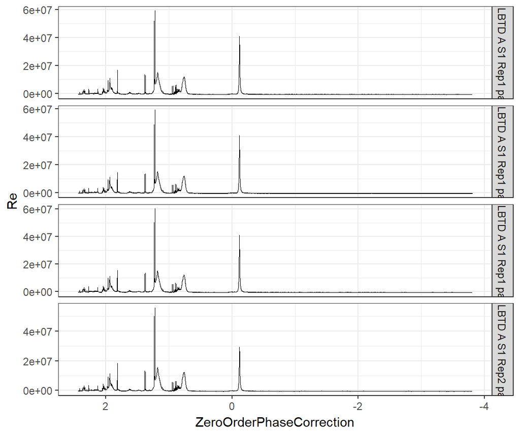

```r
# ZeroOrderPhaseCorrection
Spectrum_data <- ZeroOrderPhaseCorrection(Spectrum_data)

# ReprÃ©sentation graphique des spectres
if(DrawSpectra==T)  Draw(Re(Spectrum_data[WhichSpectra,Raw_Spec_window]), type.draw = "signal", subtype = "stacked", num.stacked=NumStack,xlab="ZeroOrderPhaseCorrection")
```

Il est difficile de le voir graphiquement mais suite à la correction de phase les pics sont exprimés au maximum dans le domaine des réels positifs (à comparer avec le précédent graphique)

## 4.2 Alignement par rapport au pic de référence (le TMSP)

Les différents spectres ne sont pas encore correctement alignés selon les mêmes fréquences. Afin de remédier à cela, nous allons utiliser une molécule de référénce (TMSP) représentée par un pic proche de 0 sur les différents spectres. Ce pic de référence sera repositionné éxactement à 0 sur l’échelle des fréquences.

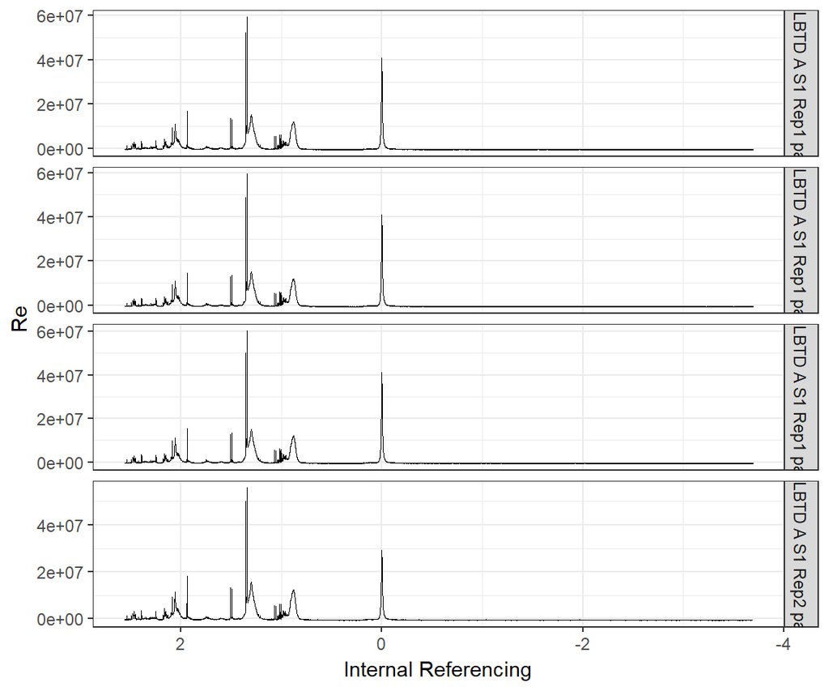

```r
Spectrum_data <- InternalReferencing(Spectrum_data, Fid_info)
# ReprÃ©sentation graphique des spectres
if(DrawSpectra==T)  Draw(Re(Spectrum_data[WhichSpectra,Raw_Spec_window]), type.draw = "signal", subtype = "stacked", num.stacked=NumStack,xlab="Internal Referencing")
```

Nous pouvons constater que l’ensemble des spectres ont été réalignés afin que le pic de référence se situe exactement à 0 sur l’echelle des fréquences.

## 4.3 Baseline correction

Après la correction de phase, une nouvelle vague peut apparaître dans les spectres (difficile à voir graphiquement). Afin de remédier à cela, nous allons utiliser une fonction de lissage assymétrique.

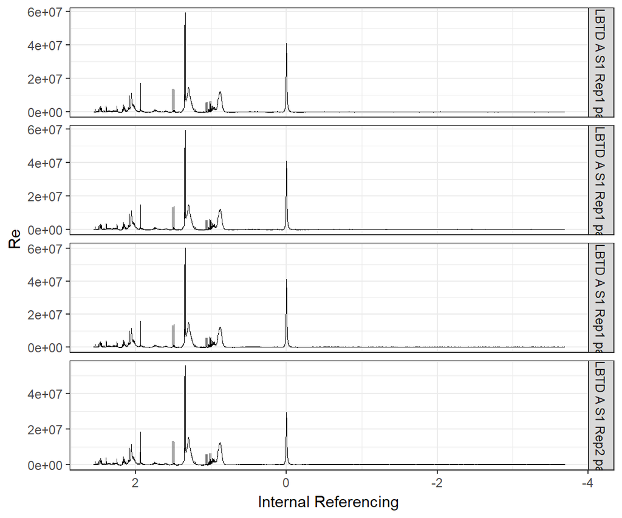

```r
Spectrum_data <- BaselineCorrection(Spectrum_data, lambda.bc = 1e+08, p.bc = 0.01)
# ReprÃ©sentation graphique des spectres
if(DrawSpectra==T)  Draw(Re(Spectrum_data[WhichSpectra,Raw_Spec_window]), type.draw = "signal", subtype = "stacked", num.stacked=NumStack,xlab="Internal Referencing")
```

## 4.4 Suppression des valeurs négatives

Suite à la précédente phase de lissage, il se peut qu’il existe encore des valeurs négatives. Dans cette étape, ces dernières seront égalisées à zero.

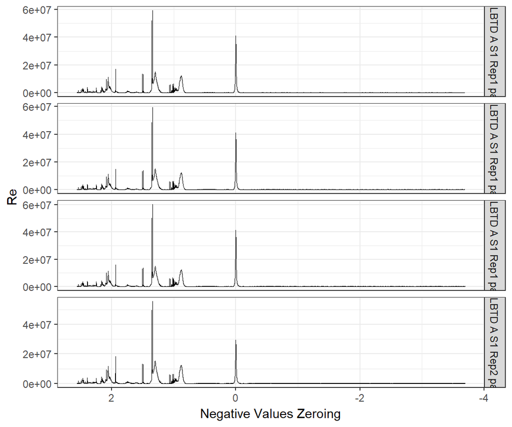

```r
Spectrum_data <- NegativeValuesZeroing(Spectrum_data)
# ReprÃ©sentation graphique des spectres
if(DrawSpectra==T)  Draw(Re(Spectrum_data[WhichSpectra,Raw_Spec_window]), type.draw = "signal", subtype = "stacked", num.stacked=NumStack,xlab="Negative Values Zeroing")
```

## 4.5 Alignement - Warping

Dans cette étape du warping, les pics qui sont similaires seront réalignés.

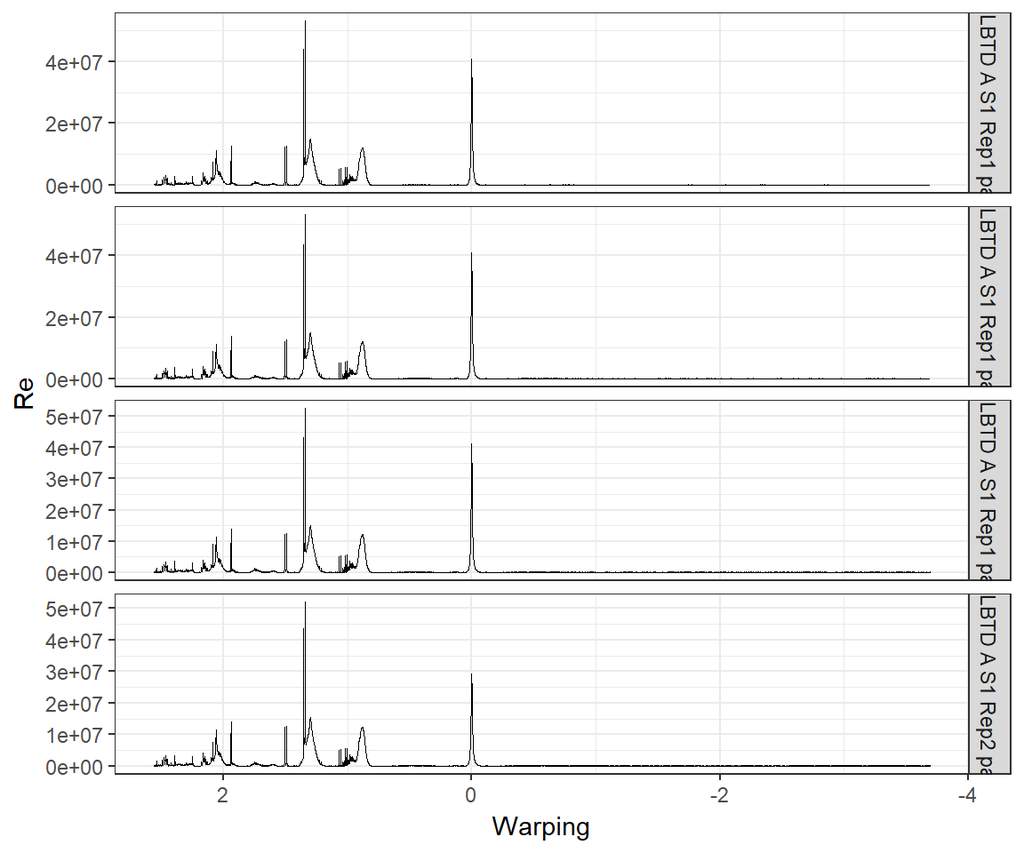

```r
if(dowarping==TRUE) Spectrum_data <- Warping(Spectrum_data,reference.choice = "before")
# ReprÃ©sentation graphique des spectres
if(DrawSpectra==T)  Draw(Re(Spectrum_data[WhichSpectra,Raw_Spec_window]), type.draw = "signal", subtype = "stacked", num.stacked=NumStack,xlab="Warping")
```

## 4.6 Window selection and Bucketing

Tout le domaine de fréquence n’est pas utile pour les analyses statistiques, nous allons donc le réduire afin de ne retenir que la partie intéressante. Le nombre de variables sera considérablement diminué.

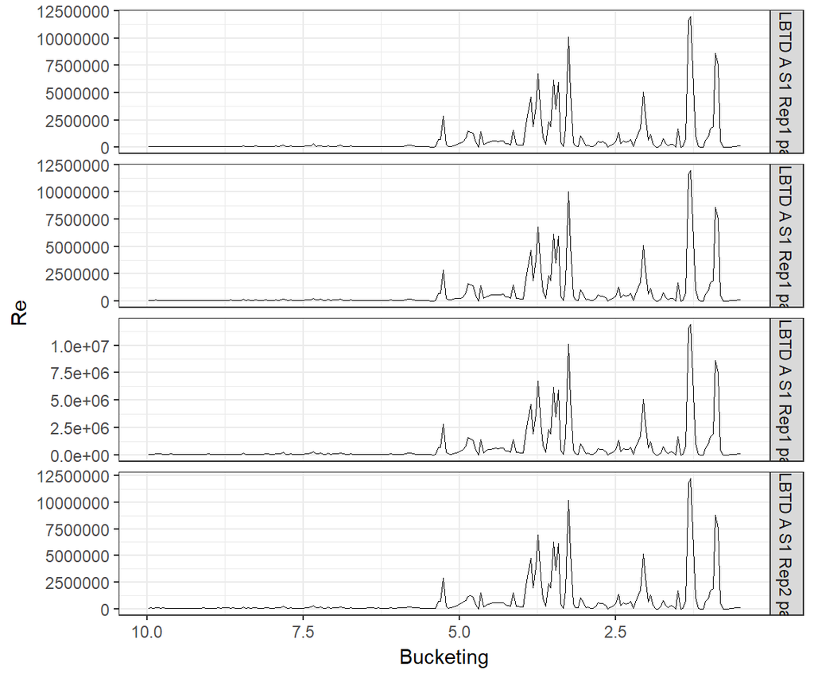

```r
Spectrum_data <- WindowSelection(Spectrum_data, from.ws = 10, to.ws = 0.48)
# Bucketing avec le Window selection intÃ©grÃ©
Spectrum_data <- Bucketing(Spectrum_data, intmeth = "t",mb=mb)
# ReprÃ©sentation graphique des spectres
if(DrawSpectra==T) Draw(Re(Spectrum_data[WhichSpectra,]), type.draw = "signal", subtype = "stacked", num.stacked=NumStack,xlab="Bucketing")
```

## 4.7 Suppression des régions non informatives

Même si la part de l’information correspondant au solvant a été supprimée dans les premières étapes, il est possible qu’il reste des régions de pics liés à ce dernier. Dans cette étape, nous allons supprimer ces régions non-informatives.

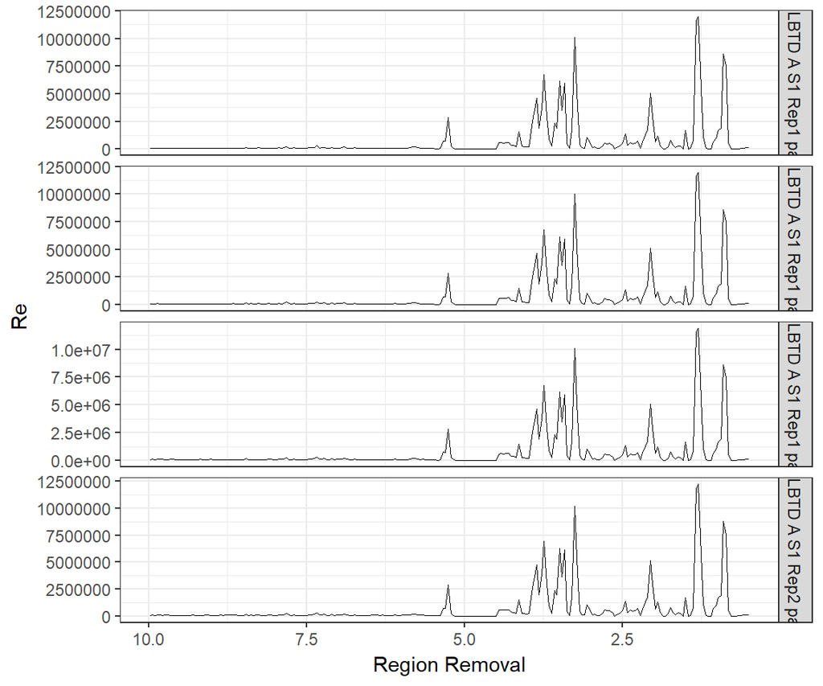

```r
# Choix de la rÃ©gion Ã  supprimer
Spectrum_data <-  RegionRemoval(Spectrum_data, typeofspectra =typeofspectra)
# ReprÃ©sentation graphique des spectres
if(DrawSpectra==T) Draw(Re(Spectrum_data[WhichSpectra,]), type.draw = "signal", subtype = "stacked", num.stacked=NumStack,xlab="Region Removal")
```

## 4.8 Agregation de zones

Il est possible que certains pics aient été mal aggrégés dans l’étape du wrapping. Dés lors, nous allons les réaligner correctement.

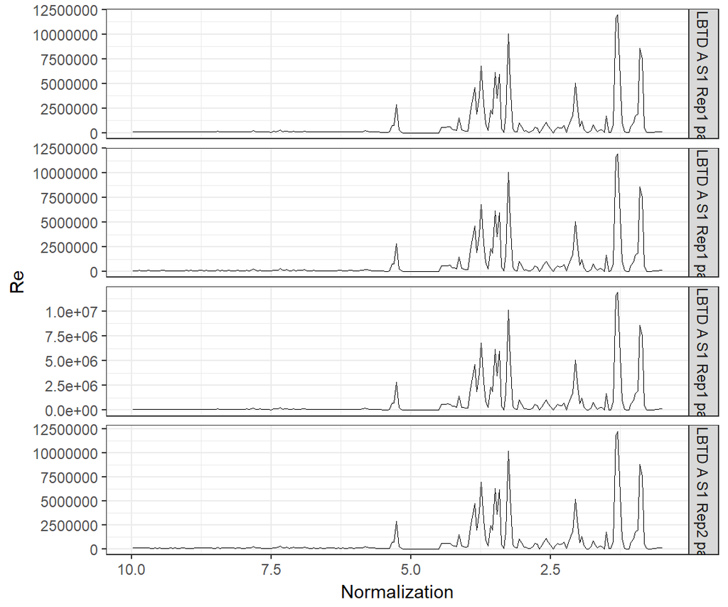

```r
# Normalization
Spectrum_data <- ZoneAggregation(Spectrum_data,
fromto.za = list(Citrate =c(2.5, 2.7)))
# ReprÃ©sentation graphique des spectres
if(DrawSpectra==T) Draw(Re(Spectrum_data[WhichSpectra,]), type.draw = "signal", subtype = "stacked", num.stacked=NumStack,xlab="Normalization")
```

## 4.9 Normalisation

La taille des pics entre les échantillons ne sont pas tout de suite comparables. En effet, par exemple, il possible qu’un échantillon avec plus de solvant ait des pics correspondants aux molécules intéressantes qui soient moins bien exprimés. Afin de remédier à cela, nous allons normaliser les données.

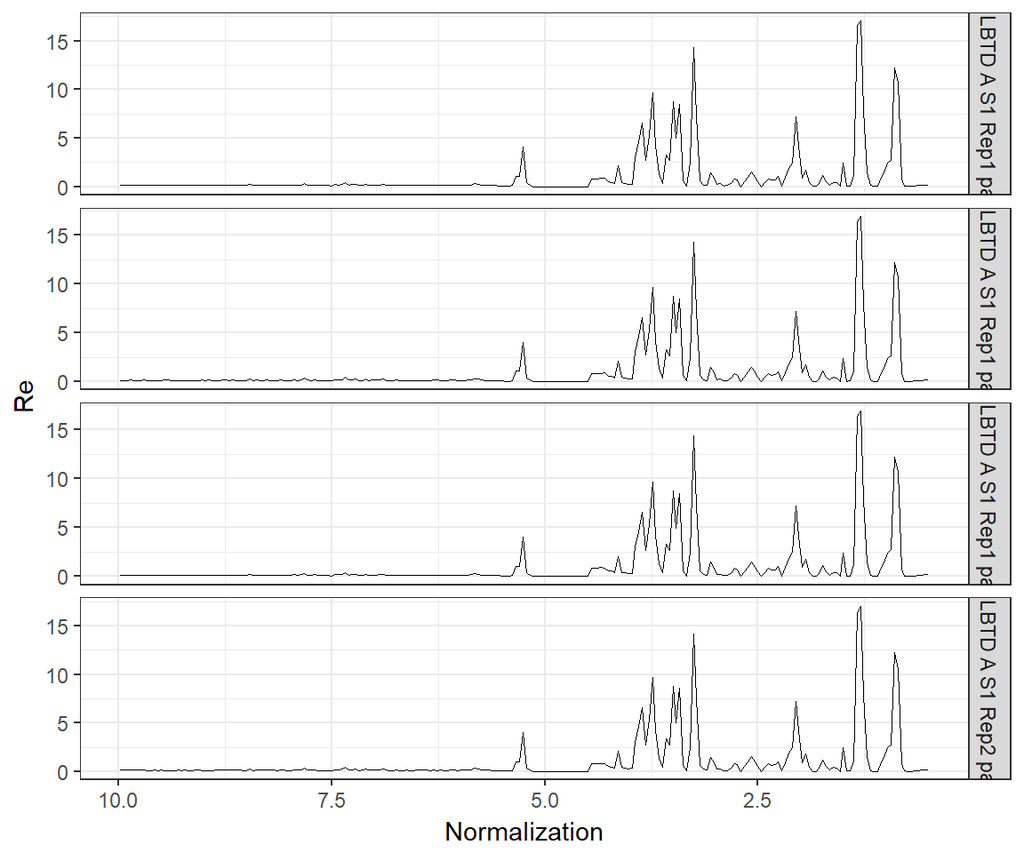

```r
# Normalization
Spectrum_data <- Normalization(Spectrum_data,type.norm="mean")
# ReprÃ©sentation graphique des spectres
if(DrawSpectra==T) Draw(Re(Spectrum_data[WhichSpectra,]), type.draw = "signal", subtype = "stacked", num.stacked=NumStack,xlab="Normalization")
```

Nous pouvons constater que l’echelle sur l’axe des ordonnées a bien été modifiée ( à comparer avec le précédent graphique).